# Lab-5-Alyssa-Walter

Author

Alyssa Walter

Published

March 21, 2025

In this lab, we will be using the `dplyr` package to explore student evaluations of teaching data.

**You are expected to use functions from `dplyr` to do your data manipulation!**

# Part 1: GitHub Workflow

Now that you have the Lab 5 repository cloned, you need to make sure you can successfully push to GitHub. To do this you need to:

- Open the `lab-5-student.qmd` file (in the lower right hand corner).
- Change the `author` line at the top of the document (in the YAML) to your name.
- Save your file either by clicking on the blue floppy disk or with a shortcut (command / control + s).
- Click the “Git” tab in upper right pane
- Check the “Staged” box for the `lab-5-student.qmd` file (the file you changed)
- Click “Commit”
- In the box that opens, type a message in “Commit message”, such as “Added my name”.
- Click “Commit”.
- Click the green “Push” button to send your local changes to GitHub.

RStudio will display something like:

```
>>> /usr/bin/git push origin HEAD:refs/heads/main
To https://github.com/atheobold/introduction-to-quarto-allison-theobold.git
   3a2171f..6d58539  HEAD -> main
```

Now you are ready to go! Remember, as you are going through the lab I would strongly recommend rendering your HTML and committing your after **every** question!

# Part 2: Some Words of Advice

Part of learning to program is learning from a variety of resources. Thus, I expect you will use resources that you find on the internet. There is, however, an important balance between copying someone else’s code and *using their code to learn*.

Therefore, if you use external resources, I want to know about it.

- If you used Google, you are expected to “inform” me of any resources you used by **pasting the link to the resource in a code comment next to where you used that resource**.
- If you used ChatGPT, you are expected to “inform” me of the assistance you received by (1) indicating somewhere in the problem that you used ChatGPT (e.g., below the question prompt or as a code comment), and (2) downloading and including the `.txt` file containing your **entire** conversation with ChatGPT.

Additionally, you are permitted and encouraged to work with your peers as you complete lab assignments, but **you are expected to do your own work**. Copying from each other is cheating, and letting people copy from you is also cheating. Please don’t do either of those things.

## Setting Up Your Code Chunks

- The first chunk of this Quarto document should be used to *declare your libraries* (probably only `tidyverse` for now).
- The second chunk of your Quarto document should be to *load in your data*.

## Save Regularly, Render Often

- Be sure to **save** your work regularly.
- Be sure to **render** your file every so often, to check for errors and make sure it looks nice.
  - Make sure your Quarto document does not contain `View(dataset)` or `install.packages("package")`, both of these will prevent rendering.
  - Check your Quarto document for occasions when you looked at the data by typing the name of the data frame. Leaving these in means the whole dataset will print out and this looks unprofessional. **Remove these!**
  - If all else fails, you can set your execution options to `error: true`, which will allow the file to render even if errors are present.

# Part 3: Let’s Start Working with the Data!

## The Data

The `teacher_evals` dataset contains student evaluations of teaching (SET) collected from students at a University in Poland. There are SET surveys from students in all fields and all levels of study offered by the university.

The SET questionnaire that every student at this university completes is as follows:

> Evaluation survey of the teaching staff of University of Poland. Please complete the following evaluation form, which aims to assess the lecturer’s performance. Only one answer should be indicated for each question. The answers are coded in the following way: 5 - I strongly agree; 4 - I agree; 3 - Neutral; 2 - I don’t agree; 1 - I strongly don’t agree.

> Question 1: I learned a lot during the course.

> Question 2: I think that the knowledge acquired during the course is very useful.

> Question 3: The professor used activities to make the class more engaging.

> Question 4: If it was possible, I would enroll for a course conducted by this lecturer again.

> Question 5: The classes started on time.

> Question 6: The lecturer always used time efficiently.

> Question 7: The lecturer delivered the class content in an understandable and efficient way.

> Question 8: The lecturer was available when we had doubts.

> Question 9. The lecturer treated all students equally regardless of their race, background and ethnicity.

These data are from the end of the winter semester of the 2020-2021 academic year. In the period of data collection, all university classes were entirely online amid the COVID-19 pandemic. While expected learning outcomes were not changed, the online mode of study could have affected grading policies and could have implications for data.

**Average SET scores** were combined with many other variables, including:

1. **characteristics of the teacher** (degree, seniority, gender, SET scores in the past 6 semesters).
2. **characteristics of the course** (time of day, day of the week, course type, course breadth, class duration, class size).
3. **percentage of students providing SET feedback.**
4. **course grades** (mean, standard deviation, percentage failed for the current course and previous 6 semesters).

This rich dataset allows us to **investigate many of the biases in student evaluations of teaching** that have been reported in the literature and to formulate new hypotheses.

Before tackling the problems below, study the description of each variable included in the `teacher_evals_codebook.pdf`.

**1. Load the appropriate R packages for your analysis.**

```r
library(tidyverse)
```

**2. Load in the `teacher_evals` data.**

```r
teacher_evals<-read.csv("data-raw/teacher_evals.csv")
```

### Data Inspection + Summary

**3. Provide a brief overview (~4 sentences) of the dataset.**

```r
glimpse(teacher_evals)
```

```
Rows: 8,015
Columns: 22
$ course_id               <chr> "0000-BHP", "0000-BHP", "0000-BHP", "0000-BHP"…
$ teacher_id              <int> 54655, 54655, 54655, 54655, 54655, 3432, 3432,…
$ question_no             <int> 901, 903, 904, 905, 907, 902, 903, 906, 909, 9…
$ no_participants         <int> 255, 255, 255, 255, 255, 998, 998, 998, 998, 1…
$ resp_share              <dbl> 0.21176471, 0.20784314, 0.21176471, 0.20784314…
$ SET_score_avg           <dbl> 4.222222, 3.679245, 3.740741, 3.301887, 3.6792…
$ stud_grade_avg          <dbl> 3.000000, 3.000000, 3.000000, 3.000000, 3.0000…
$ stud_grade_std          <dbl> 0.0000000, 0.0000000, 0.0000000, 0.0000000, 0.…
$ stud_grade_var_coef     <dbl> 0.0000000, 0.0000000, 0.0000000, 0.0000000, 0.…
$ percent_failed          <dbl> 0.000000000, 0.000000000, 0.000000000, 0.00000…
$ stud_grade_avg_cur      <dbl> 3.000000, 3.000000, 3.000000, 3.000000, 3.0000…
$ stud_grade_std_cur      <dbl> 0.0000000, 0.0000000, 0.0000000, 0.0000000, 0.…
$ stud_grade_var_coef_cur <dbl> 0.0000000, 0.0000000, 0.0000000, 0.0000000, 0.…
$ percent_failed_cur      <dbl> 0.000000000, 0.000000000, 0.000000000, 0.00000…
$ class_duration          <dbl> 0, 0, 0, 0, 0, 0, 0, 0, 0, 0, 0, 0, 0, 0, 0, 0…
$ weekday                 <chr> "Friday", "Friday", "Friday", "Friday", "Frida…
$ time_of_day             <chr> "<10", "<10", "<10", "<10", "<10", "14-18", "1…
$ SET_score_1sem          <dbl> 3.820000, 3.820000, 3.820000, 3.820000, 3.8200…
$ maximum_score           <int> 0, 0, 0, 0, 0, 0, 0, 0, 0, 0, 0, 0, 0, 0, 0, 0…
$ academic_degree         <chr> "no_dgr", "no_dgr", "no_dgr", "no_dgr", "no_dg…
$ seniority               <int> 4, 4, 4, 4, 4, 11, 11, 11, 11, 11, 11, 11, 11,…
$ gender                  <chr> "male", "male", "male", "male", "male", "male"…
```

```r
dim(teacher_evals)
```

```
[1] 8015   22
```

> This dataset includes student evaluations of their teachers, and information about the teacher’s educational experience and gender. Student grades and class averages are also represented in the dataset, so we have the ability to compare student performance to teacher experience level. Class time and day of the week are also variables included in the student evaluations, so we can expore whether there is any relationship between class time and student performance.

**4. What is the unit of observation (i.e. a single row in the dataset) identified by?**

```r
# you may want to use code to answer this question
```

> The unit of observation is each question on the student evaluation. Each row in the dataset is the class average of student results for a single question and teacher of a class.

**5. Use *one* `dplyr` pipeline to clean the data by:**

- **renaming the `gender` variable `sex`**
- **removing all courses with fewer than 10 respondents**
- **changing data types in whichever way you see fit (e.g., is the instructor ID really a numeric data type?)**
- **only keeping the columns we will use – `course_id`, `teacher_id`, `question_no`, `no_participants`, `resp_share`, `SET_score_avg`, `percent_failed_cur`, `academic_degree`, `seniority`, and `sex`**

**Assign your cleaned data to a new variable named `teacher_evals_clean` –- use these data going forward. Save the data as `teacher_evals_clean.csv` in the `data-clean` folder.**

```r
teacher_evals_clean <- teacher_evals|>
  rename(sex = gender) |> #rename gender as sex
  filter(no_participants >= 10) |> #select only classes with 10 or more students
  mutate(
    teacher_id = as.character(teacher_id),  #change teacher_id to a character
    question_no = as.character(question_no) #change question_no to a character
  ) |>
  select(course_id, teacher_id, question_no, no_participants, resp_share,
         SET_score_avg, percent_failed_cur, academic_degree, seniority, sex) |> #keeping only the columns we want
  write_csv("data-clean/teacher_evals_clean.csv") #saving clean data
```

**6. How many unique instructors and unique courses are present in the cleaned dataset?**

```r
teacher_evals_clean|>
  summarise( unique_instructors = n_distinct(teacher_id),
    unique_courses = n_distinct(course_id)) #count number of unique teachers and courses
```

```
  unique_instructors unique_courses
1                297            939
```

> There are 297 unique instructors and 939 courses.

**7. One teacher-course combination has some missing values, coded as `NA`. Which instructor has these missing values? Which course? What variable are the missing values in?**

```r
teacher_evals_clean|>
  filter(if_any(everything(), is.na))  # filter for rows with na values
```

```
    course_id teacher_id question_no no_participants resp_share SET_score_avg
1 PAB3SE004PA      56347         901              32    0.03125             5
2 PAB3SE004PA      56347         902              32    0.03125             5
3 PAB3SE004PA      56347         903              32    0.03125             4
4 PAB3SE004PA      56347         905              32    0.03125             4
5 PAB3SE004PA      56347         906              32    0.03125             3
6 PAB3SE004PA      56347         907              32    0.03125             3
7 PAB3SE004PA      56347         908              32    0.03125             5
  percent_failed_cur academic_degree seniority    sex
1                 NA              ma         4 female
2                 NA              ma         4 female
3                 NA              ma         4 female
4                 NA              ma         4 female
5                 NA              ma         4 female
6                 NA              ma         4 female
7                 NA              ma         4 female
```

> Instructor 56347 in class PAB3SE004PA had missing values in the percent failed column.

**8. What are the demographics of the instructors in this study? Investigate the variables `academic_degree`, `seniority`, and `sex` and summarize your findings in ~3 complete sentences.**

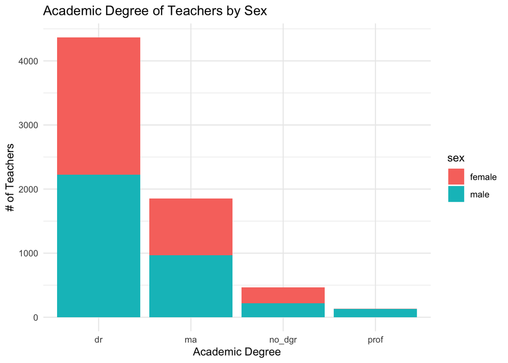

```r
# degree barplot
ggplot(teacher_evals_clean, aes(x = academic_degree, fill = sex)) +
  geom_bar(position = "stack") +
  labs(title = "Academic Degree of Teachers by Sex", x = "Academic Degree", y = "# of Teachers") +
  theme_minimal()
```

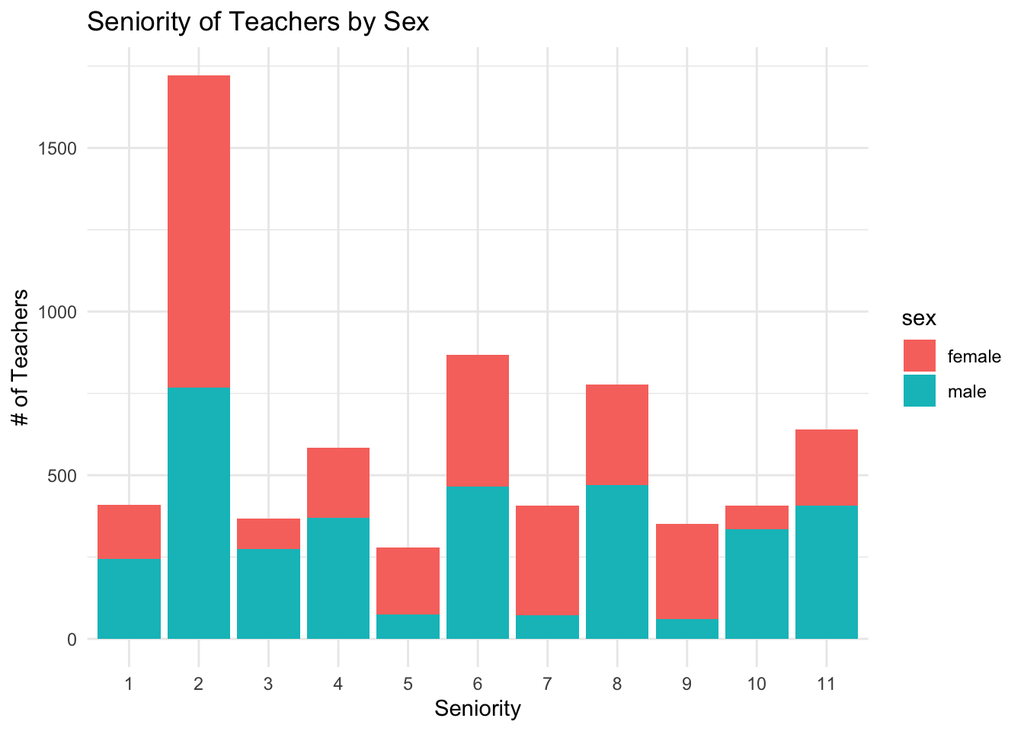

```r
# seniority barplot
ggplot(teacher_evals_clean, aes(x = as.factor(seniority), fill = sex)) +
  geom_bar(position = "stack") +
  labs(title = "Seniority of Teachers by Sex", x = "Seniority", y = "# of Teachers") +
  theme_minimal()
```

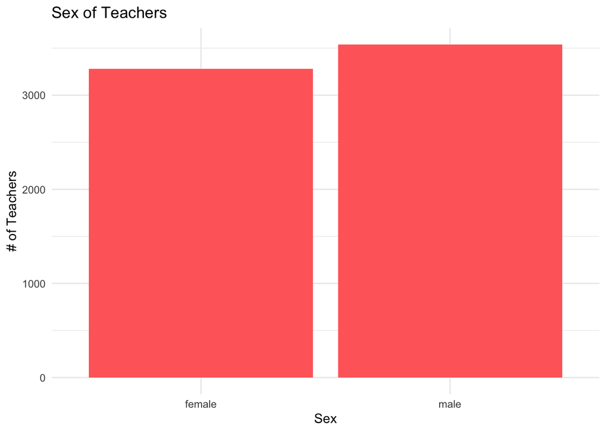

```r
# sex of teachers barplot
ggplot(teacher_evals_clean, aes(x = sex)) +
  geom_bar(fill = "indianred1") +
  labs(title = "Sex of Teachers", x = "Sex", y = "# of Teachers") +
  theme_minimal()
```

**9. Each course seems to have used a different subset of the nine evaluation questions. How many teacher-course combinations asked all nine questions?**

```r
teacher_evals_clean|>
  group_by(course_id, teacher_id)|> #group by teacher and course
  summarise(unique_questions = n_distinct(question_no)) |> #find the number of questions asked in each course
  filter(unique_questions == 9) #select courses who asked all 9 questions
```

```
# A tibble: 49 × 3
# Groups:   course_id [48]
   course_id       teacher_id unique_questions
   <chr>           <chr>                 <int>
 1 0000-SEM-SP     38335                     9
 2 ARI3SE001AR-PDW 50752                     9
 3 ARI3SP17AR-Z18  69447                     9
 4 CII2SE02CI-L19  3662                      9
 5 CII3SP12CI-Z17  3521                      9
 6 CII7SE05CI-Z19  57632                     9
 7 CII7SP02CI-Z20  54309                     9
 8 CII7SP08CI-Z19  44665                     9
 9 CIM3SE01SJO-Z19 59070                     9
10 ECB3NP02EC-Z20  38588                     9
# ℹ 39 more rows
```

> There are 49 teacher-course combinations who asked all 9 questions

## Rate my Professor

**10. Which instructors had the highest and lowest average rating for Question 1 (I learnt a lot during the course.) across all their courses?**

```r
teacher_evals_clean|>
  filter(question_no == 901)|> #filter for question 1
  group_by(teacher_id, course_id) |> #group by teacher and course
  summarise(avg_rating = mean(SET_score_avg, na.rm = TRUE)) |> #average scores for each teacher across their courses
  ungroup() |>
  summarise(
    highest_teacher = teacher_id[which.max(avg_rating)],
    lowest_teacher = teacher_id[which.min(avg_rating)],
    highest_rating = max(avg_rating),
    lowest_rating = min(avg_rating))
```

```
# A tibble: 1 × 4
  highest_teacher lowest_teacher highest_rating lowest_rating
  <chr>           <chr>                   <dbl>         <dbl>
1 100131          100132                      5             1
```

> 100131 had the highest average SET score and 100132 had the lowest.

> I recieved help with which. functions from https://r-coder.com/which-max-min-r/

**11. Which instructors with one year of experience had the highest and lowest average percentage of students failing in the current semester across all their courses?**

```r
teacher_evals_clean |>
  filter(seniority == 1) |> #filter for a seniority level of 1
  group_by(teacher_id) |>
    summarise(
    avg_fail_percent = mean(percent_failed_cur, na.rm = TRUE)
  ) |> #average fail rate across all the teachers classes
  ungroup() |>
  summarise(
    min_fail_teacher = teacher_id[which.min(avg_fail_percent)],# find the min fail rate
    max_fail_teacher = teacher_id[which.max(avg_fail_percent)],# find the max fail rate
    min_fail = min(avg_fail_percent),
    max_fail = max(avg_fail_percent)
  )
```

```
# A tibble: 1 × 4
  min_fail_teacher max_fail_teacher min_fail max_fail
  <chr>            <chr>               <dbl>    <dbl>
1 102379           106692                  0     0.68
```

**12. Which female instructors with either a doctorate or professional degree had the highest and lowest average percent of students responding to the evaluation across all their courses?**

```r
teacher_evals_clean |>
  filter(sex == "female",
         (academic_degree == "dr" | academic_degree == "prof")) |> #filter for females with doctorates and prof degrees
  group_by(teacher_id) |>
  summarise(
    avg_resp_share = mean(resp_share, na.rm = TRUE) #calculate the mean % of students who responded for each teacher across all courses
  ) |>
  ungroup() |>
  summarise(
    min_resp_teacher = teacher_id[which.min(avg_resp_share)],
    max_resp_teacher = teacher_id[which.max(avg_resp_share)],
    min_resp = min(avg_resp_share), #print the minimum number responses
    max_resp = max(avg_resp_share)) #print the maximum number responses
```

```
# A tibble: 1 × 4
  min_resp_teacher max_resp_teacher min_resp max_resp
  <chr>            <chr>               <dbl>    <dbl>
1 59338            101508             0.0148    0.522
```

> Female instructor 59338 had the lowest response rate, and instructor 101508 had the highest.